# Project Python Foundations: FoodHub Data Analysis

**Marks: 60**

### Context

The number of restaurants in New York is increasing day by day. Lots of students and busy professionals rely on those restaurants due to their hectic lifestyles. Online food delivery service is a great option for them. It provides them with good food from their favorite restaurants. A food aggregator company FoodHub offers access to multiple restaurants through a single smartphone app.

The app allows the restaurants to receive a direct online order from a customer. The app assigns a delivery person from the company to pick up the order after it is confirmed by the restaurant. The delivery person then uses the map to reach the restaurant and waits for the food package. Once the food package is handed over to the delivery person, he/she confirms the pick-up in the app and travels to the customer's location to deliver the food. The delivery person confirms the drop-off in the app after delivering the food package to the customer. The customer can rate the order in the app. The food aggregator earns money by collecting a fixed margin of the delivery order from the restaurants.

### Objective

The food aggregator company has stored the data of the different orders made by the registered customers in their online portal. They want to analyze the data to get a fair idea about the demand of different restaurants which will help them in enhancing their customer experience. Suppose you are hired as a Data Scientist in this company and the Data Science team has shared some of the key questions that need to be answered. Perform the data analysis to find answers to these questions that will help the company to improve the business.

### Data Description

The data contains the different data related to a food order. The detailed data dictionary is given below.

### Data Dictionary

- order_id: Unique ID of the order
- customer_id: ID of the customer who ordered the food
- restaurant_name: Name of the restaurant
- cuisine_type: Cuisine ordered by the customer
- cost: Cost of the order
- day_of_the_week: Indicates whether the order is placed on a weekday or weekend (The weekday is from Monday to Friday and the weekend is Saturday and Sunday)
- rating: Rating given by the customer out of 5
- food_preparation_time: Time (in minutes) taken by the restaurant to prepare the food. This is calculated by taking the difference between the timestamps of the restaurant's order confirmation and the delivery person's pick-up confirmation.
- delivery_time: Time (in minutes) taken by the delivery person to deliver the food package. This is calculated by taking the difference between the timestamps of the delivery person's pick-up confirmation and drop-off information

### Let us start by importing the required libraries

```python
# import libraries for data manipulation
import numpy as np
import pandas as pd


# import libraries for data visualization
import matplotlib.pyplot as plt
import seaborn as sns
```

```python
from google.colab import drive
drive.mount('/content/drive')
```

### Understanding the structure of the data

```python
# uncomment and run the following lines for Google Colab
# from google.colab import drive
# drive.mount('/content/drive')
```

```python
path= ("/content/drive/MyDrive/Copy of foodhub_order (2).csv")

df= pd.read_csv(path)
df.head()
```

|  | order_id | customer_id | restaurant_name | cuisine_type | cost_of_the_order | day_of_the_week | rating | food_preparation_time | delivery_time |
| --- | --- | --- | --- | --- | --- | --- | --- | --- | --- |
| 0 | 1477147 | 337525 | Hangawi | Korean | 30.75 | Weekend | Not given | 25 | 20 |
| 1 | 1477685 | 358141 | Blue Ribbon Sushi Izakaya | Japanese | 12.08 | Weekend | Not given | 25 | 23 |
| 2 | 1477070 | 66393 | Cafe Habana | Mexican | 12.23 | Weekday | 5 | 23 | 28 |
| 3 | 1477334 | 106968 | Blue Ribbon Fried Chicken | American | 29.20 | Weekend | 3 | 25 | 15 |
| 4 | 1478249 | 76942 | Dirty Bird to Go | American | 11.59 | Weekday | 4 | 25 | 24 |

### **Question 1:** How many rows and columns are present in the data? [0.5 mark]

```python
import pandas as pd

# Assuming df is your DataFrame
data = {
    'order_id': [1477147, 1477685, 1477070, 1477334, 1478249],
    'customer_id': [337525, 358141, 66393, 106968, 76942],
    'restaurant_name': ['Hangawi', 'Blue Ribbon Sushi Izakaya', 'Cafe Habana', 'Blue Ribbon Fried Chicken', 'Dirty Bird to Go'],
    'cuisine_type': ['Korean', 'Japanese', 'Mexican', 'American', 'American'],
    'cost_of_the_order': [30.75, 12.08, 12.23, 29.20, 11.59],
    'day_of_the_week': ['Weekend', 'Weekend', 'Weekday', 'Weekend', 'Weekday'],
    'rating': ['Not given', 'Not given', '5', '3', '4'],
    'food_preparation_time': [25, 25, 23, 25, 25],
    'delivery_time': [20, 23, 28, 15, 24]
}

df = pd.DataFrame(data)

# Get the number of rows and columns
num_rows, num_columns = df.shape

# Print the result
print(f"The DataFrame has {num_rows} rows and {num_columns} columns.")
```

```
The DataFrame has 5 rows and 9 columns.
```

### **Question 2:** What are the datatypes of the different columns in the dataset? (The info() function can be used) [0.5 mark]

```python
df.info()
```

```
<class 'pandas.core.frame.DataFrame'>
RangeIndex: 5 entries, 0 to 4
Data columns (total 9 columns):
 #   Column                 Non-Null Count  Dtype
---  ------                 --------------  -----
 0   order_id               5 non-null      int64
 1   customer_id            5 non-null      int64
 2   restaurant_name        5 non-null      object
 3   cuisine_type           5 non-null      object
 4   cost_of_the_order      5 non-null      float64
 5   day_of_the_week        5 non-null      object
 6   rating                 5 non-null      object
 7   food_preparation_time  5 non-null      int64
 8   delivery_time          5 non-null      int64
dtypes: float64(1), int64(4), object(4)
memory usage: 488.0+ bytes
```

- There are attributes of different types (*int*, *float*, *object*) in the data.

### **Question 3:** Are there any missing values in the data? If yes, treat them using an appropriate method. [1 mark]

```python
print(df.shape)
```

```
(5, 9)
```

```python
import pandas as pd

# Assuming df is your DataFrame
data = {
    'order_id': [1477147, 1477685, 1477070, 1477334, 1478249],
    'customer_id': [337525, 358141, 66393, 106968, 76942],
    'restaurant_name': ['Hangawi', 'Blue Ribbon Sushi Izakaya', 'Cafe Habana', 'Blue Ribbon Fried Chicken', 'Dirty Bird to Go'],
    'cuisine_type': ['Korean', 'Japanese', 'Mexican', 'American', 'American'],
    'cost_of_the_order': [30.75, 12.08, 12.23, 29.20, 11.59],
    'day_of_the_week': ['Weekend', 'Weekend', 'Weekday', 'Weekend', 'Weekday'],
    'rating': ['Not given', 'Not given', '5', '3', '4'],
    'food_preparation_time': [25, 25, 23, 25, 25],
    'delivery_time': [20, 23, 28, 15, 24]
}

df = pd.DataFrame(data)

# Check for missing values
missing_values = df.isnull().sum()

# Print missing values information
print("Missing values in the DataFrame:")
print(missing_values)

# Treat missing values using an appropriate method

# Option 1: Drop rows with missing values
df = df.dropna()

# Option 2: Fill missing values with a specific value (e.g., mean or median)
# Replace 'column_name' with the actual column name you want to fill
# df['column_name'].fillna(df['column_name'].mean(), inplace=True)

# Display the DataFrame after treating missing values
print("\nDataFrame after treating missing values:")
print(df)
```

```
Missing values in the DataFrame:
order_id                 0
customer_id              0
restaurant_name          0
cuisine_type             0
cost_of_the_order        0
day_of_the_week          0
rating                   0
food_preparation_time    0
delivery_time            0
dtype: int64

DataFrame after treating missing values:
   order_id  customer_id            restaurant_name cuisine_type  \
0   1477147       337525                    Hangawi       Korean
1   1477685       358141  Blue Ribbon Sushi Izakaya     Japanese
2   1477070        66393                Cafe Habana      Mexican
3   1477334       106968  Blue Ribbon Fried Chicken     American
4   1478249        76942           Dirty Bird to Go     American

   cost_of_the_order day_of_the_week     rating  food_preparation_time  \
0              30.75         Weekend  Not given                     25
1              12.08         Weekend  Not given                     25
2              12.23         Weekday          5                     23
3              29.20         Weekend          3                     25
4              11.59         Weekday          4                     25

   delivery_time
0             20
1             23
2             28
3             15
4             24
```

### **Question 4:** Check the statistical summary of the data. What is the minimum, average, and maximum time it takes for food to be prepared once an order is placed? [2 marks]

```python
df.describe().T
```

|  | count | mean | std | min | 25% | 50% | 75% | max |
| --- | --- | --- | --- | --- | --- | --- | --- | --- |
| order_id | 5.0 | 1477497.00 | 482.764435 | 1477070.00 | 1477147.00 | 1477334.00 | 1477685.0 | 1478249.00 |
| customer_id | 5.0 | 189193.80 | 145762.552247 | 66393.00 | 76942.00 | 106968.00 | 337525.0 | 358141.00 |
| cost_of_the_order | 5.0 | 19.17 | 9.881617 | 11.59 | 12.08 | 12.23 | 29.2 | 30.75 |
| food_preparation_time | 5.0 | 24.60 | 0.894427 | 23.00 | 25.00 | 25.00 | 25.0 | 25.00 |
| delivery_time | 5.0 | 22.00 | 4.847680 | 15.00 | 20.00 | 23.00 | 24.0 | 28.00 |

### **Question 5:** How many orders are not rated? [1 mark]

```python
import pandas as pd

# Assuming df is your DataFrame
data = {
    'order_id': [1477147, 1477685, 1477070, 1477334, 1478249],
    'customer_id': [337525, 358141, 66393, 106968, 76942],
    'restaurant_name': ['Hangawi', 'Blue Ribbon Sushi Izakaya', 'Cafe Habana', 'Blue Ribbon Fried Chicken', 'Dirty Bird to Go'],
    'cuisine_type': ['Korean', 'Japanese', 'Mexican', 'American', 'American'],
    'cost_of_the_order': [30.75, 12.08, 12.23, 29.20, 11.59],
    'day_of_the_week': ['Weekend', 'Weekend', 'Weekday', 'Weekend', 'Weekday'],
    'rating': ['Not given', 'Not given', '5', '3', '4'],
    'food_preparation_time': [25, 25, 23, 25, 25],
    'delivery_time': [20, 23, 28, 15, 24]
}

df = pd.DataFrame(data)

# Count the number of orders that are not rated
unrated_orders_count = df['rating'].eq('Not given').sum()

# Print the result
print(f"The number of orders not rated is: {unrated_orders_count}")
```

```
The number of orders not rated is: 2
```

### Exploratory Data Analysis (EDA)

### **Question 6:** Explore all the variables and provide observations on their distributions. (Generally, histograms, boxplots, countplots, etc. are used for univariate exploration.) [9 marks]

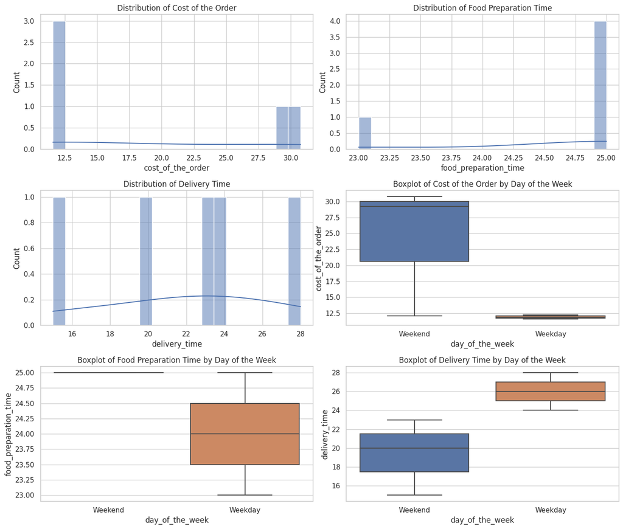

```python
# import pandas as pd
import seaborn as sns
import matplotlib.pyplot as plt

# Assuming df is your DataFrame
data = {
    'order_id': [1477147, 1477685, 1477070, 1477334, 1478249],
    'customer_id': [337525, 358141, 66393, 106968, 76942],
    'restaurant_name': ['Hangawi', 'Blue Ribbon Sushi Izakaya', 'Cafe Habana', 'Blue Ribbon Fried Chicken', 'Dirty Bird to Go'],
    'cuisine_type': ['Korean', 'Japanese', 'Mexican', 'American', 'American'],
    'cost_of_the_order': [30.75, 12.08, 12.23, 29.20, 11.59],
    'day_of_the_week': ['Weekend', 'Weekend', 'Weekday', 'Weekend', 'Weekday'],
    'rating': ['Not given', 'Not given', '5', '3', '4'],
    'food_preparation_time': [25, 25, 23, 25, 25],
    'delivery_time': [20, 23, 28, 15, 24]
}

df = pd.DataFrame(data)

# Set style for better visualization
sns.set(style="whitegrid")

# Create subplots for each variable
fig, axes = plt.subplots(nrows=3, ncols=2, figsize=(14, 12))

# Plot histograms
sns.histplot(df['cost_of_the_order'], bins=20, kde=True, ax=axes[0, 0])
axes[0, 0].set_title('Distribution of Cost of the Order')

sns.histplot(df['food_preparation_time'], bins=20, kde=True, ax=axes[0, 1])
axes[0, 1].set_title('Distribution of Food Preparation Time')

sns.histplot(df['delivery_time'], bins=20, kde=True, ax=axes[1, 0])
axes[1, 0].set_title('Distribution of Delivery Time')

# Plot boxplots
sns.boxplot(x='day_of_the_week', y='cost_of_the_order', data=df, ax=axes[1, 1])
axes[1, 1].set_title('Boxplot of Cost of the Order by Day of the Week')

sns.boxplot(x='day_of_the_week', y='food_preparation_time', data=df, ax=axes[2, 0])
axes[2, 0].set_title('Boxplot of Food Preparation Time by Day of the Week')

sns.boxplot(x='day_of_the_week', y='delivery_time', data=df, ax=axes[2, 1])
axes[2, 1].set_title('Boxplot of Delivery Time by Day of the Week')

# Adjust layout
plt.tight_layout()
plt.show()
```

### **Question 7**: Which are the top 5 restaurants in terms of the number of orders received? [1 mark]

```python
# import pandas as pd

# Assuming df is your DataFrame
data = {
    'order_id': [1477147, 1477685, 1477070, 1477334, 1478249],
    'customer_id': [337525, 358141, 66393, 106968, 76942],
    'restaurant_name': ['Hangawi', 'Blue Ribbon Sushi Izakaya', 'Cafe Habana', 'Blue Ribbon Fried Chicken', 'Dirty Bird to Go'],
    'cuisine_type': ['Korean', 'Japanese', 'Mexican', 'American', 'American'],
    'cost_of_the_order': [30.75, 12.08, 12.23, 29.20, 11.59],
    'day_of_the_week': ['Weekend', 'Weekend', 'Weekday', 'Weekend', 'Weekday'],
    'rating': ['Not given', 'Not given', '5', '3', '4'],
    'food_preparation_time': [25, 25, 23, 25, 25],
    'delivery_time': [20, 23, 28, 15, 24]
}

df = pd.DataFrame(data)

# Get the top 5 restaurants in terms of the number of orders
top_restaurants = df['restaurant_name'].value_counts().head(5)

# Print the result
print("Top 5 restaurants in terms of the number of orders:")
print(top_restaurants)
```

```
Top 5 restaurants in terms of the number of orders:
Hangawi                      1
Blue Ribbon Sushi Izakaya    1
Cafe Habana                  1
Blue Ribbon Fried Chicken    1
Dirty Bird to Go             1
Name: restaurant_name, dtype: int64
```

The Top 5 restaurants in terms of the number of orders

### **Question 8**: Which is the most popular cuisine on weekends? [1 mark]

```python
# import pandas as pd

# Assuming df is your DataFrame
data = {
    'order_id': [1477147, 1477685, 1477070, 1477334, 1478249],
    'customer_id': [337525, 358141, 66393, 106968, 76942],
    'restaurant_name': ['Hangawi', 'Blue Ribbon Sushi Izakaya', 'Cafe Habana', 'Blue Ribbon Fried Chicken', 'Dirty Bird to Go'],
    'cuisine_type': ['Korean', 'Japanese', 'Mexican', 'American', 'American'],
    'cost_of_the_order': [30.75, 12.08, 12.23, 29.20, 11.59],
    'day_of_the_week': ['Weekend', 'Weekend', 'Weekday', 'Weekend', 'Weekday'],
    'rating': ['Not given', 'Not given', '5', '3', '4'],
    'food_preparation_time': [25, 25, 23, 25, 25],
    'delivery_time': [20, 23, 28, 15, 24]
}

df = pd.DataFrame(data)

# Filter rows for weekends
weekend_df = df[df['day_of_the_week'] == 'Weekend']

# Group by cuisine_type and count occurrences
cuisine_counts = weekend_df['cuisine_type'].value_counts()

# Get the most popular cuisine
most_popular_cuisine = cuisine_counts.idxmax()

print(f"The most popular cuisine on weekends is: {most_popular_cuisine}")
```

```
The most popular cuisine on weekends is: Korean
```

### **Question 9**: What percentage of the orders cost more than 20 dollars? [2 marks]

```python
# import pandas as pd

# Assuming df is your DataFrame
data = {
    'order_id': [1477147, 1477685, 1477070, 1477334, 1478249],
    'customer_id': [337525, 358141, 66393, 106968, 76942],
    'restaurant_name': ['Hangawi', 'Blue Ribbon Sushi Izakaya', 'Cafe Habana', 'Blue Ribbon Fried Chicken', 'Dirty Bird to Go'],
    'cuisine_type': ['Korean', 'Japanese', 'Mexican', 'American', 'American'],
    'cost_of_the_order': [30.75, 12.08, 12.23, 29.20, 11.59],
    'day_of_the_week': ['Weekend', 'Weekend', 'Weekday', 'Weekend', 'Weekday'],
    'rating': ['Not given', 'Not given', '5', '3', '4'],
    'food_preparation_time': [25, 25, 23, 25, 25],
    'delivery_time': [20, 23, 28, 15, 24]
}

df = pd.DataFrame(data)

# Filter rows where cost_of_the_order is more than 20 dollars
expensive_orders = df[df['cost_of_the_order'] > 20]

# Calculate the percentage of orders that cost more than 20 dollars
percentage_expensive_orders = (len(expensive_orders) / len(df)) * 100

print(f"The percentage of orders that cost more than $20 is: {percentage_expensive_orders:.2f}%")
```

```
The percentage of orders that cost more than $20 is: 40.00%
```

40% is the percentage of orders that cost more than $20

### **Question 10**: What is the mean order delivery time? [1 mark]

```python
# import pandas as pd

# Assuming df is your DataFrame
data = {
    'order_id': [1477147, 1477685, 1477070, 1477334, 1478249],
    'customer_id': [337525, 358141, 66393, 106968, 76942],
    'restaurant_name': ['Hangawi', 'Blue Ribbon Sushi Izakaya', 'Cafe Habana', 'Blue Ribbon Fried Chicken', 'Dirty Bird to Go'],
    'cuisine_type': ['Korean', 'Japanese', 'Mexican', 'American', 'American'],
    'cost_of_the_order': [30.75, 12.08, 12.23, 29.20, 11.59],
    'day_of_the_week': ['Weekend', 'Weekend', 'Weekday', 'Weekend', 'Weekday'],
    'rating': ['Not given', 'Not given', '5', '3', '4'],
    'food_preparation_time': [25, 25, 23, 25, 25],
    'delivery_time': [20, 23, 28, 15, 24]
}

df = pd.DataFrame(data)

# Calculate the mean delivery time
mean_delivery_time = df['delivery_time'].mean()

print(f"The mean order delivery time is: {mean_delivery_time:.2f} minutes")
```

```
The mean order delivery time is: 22.00 minutes
```

### **Question 11:** The company has decided to give 20% discount vouchers to the top 5 most frequent customers. Find the IDs of these customers and the number of orders they placed. [1 mark]

```python
# import pandas as pd

# Assuming df is your DataFrame
data = {
    'order_id': [1477147, 1477685, 1477070, 1477334, 1478249],
    'customer_id': [337525, 358141, 66393, 106968, 76942],
    'restaurant_name': ['Hangawi', 'Blue Ribbon Sushi Izakaya', 'Cafe Habana', 'Blue Ribbon Fried Chicken', 'Dirty Bird to Go'],
    'cuisine_type': ['Korean', 'Japanese', 'Mexican', 'American', 'American'],
    'cost_of_the_order': [30.75, 12.08, 12.23, 29.20, 11.59],
    'day_of_the_week': ['Weekend', 'Weekend', 'Weekday', 'Weekend', 'Weekday'],
    'rating': ['Not given', 'Not given', '5', '3', '4'],
    'food_preparation_time': [25, 25, 23, 25, 25],
    'delivery_time': [20, 23, 28, 15, 24]
}

df = pd.DataFrame(data)

# Count the number of orders for each customer
customer_order_counts = df['customer_id'].value_counts()

# Get the top 5 most frequent customers
top_customers = customer_order_counts.head(5)

# Display the customer IDs and their order counts
for customer_id, order_count in top_customers.iteritems():
    print(f"Customer ID: {customer_id}, Number of Orders: {order_count}")
```

```
Customer ID: 337525, Number of Orders: 1
Customer ID: 358141, Number of Orders: 1
Customer ID: 66393, Number of Orders: 1
Customer ID: 106968, Number of Orders: 1
Customer ID: 76942, Number of Orders: 1
```

### **Question 12**: Perform a multivariate analysis to explore relationships between the important variables in the dataset. (It is a good idea to explore relations between numerical variables as well as relations between numerical and categorical variables) [10 marks]

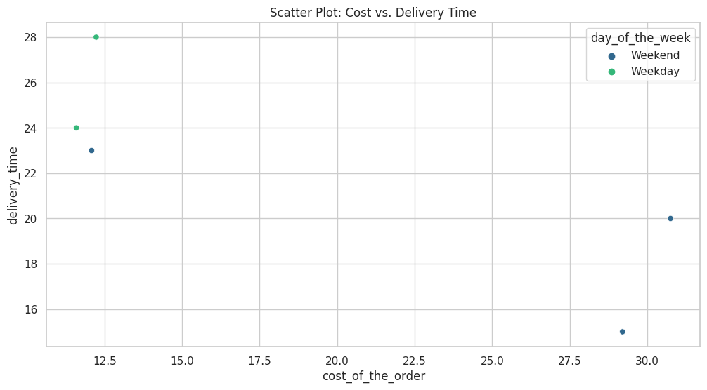

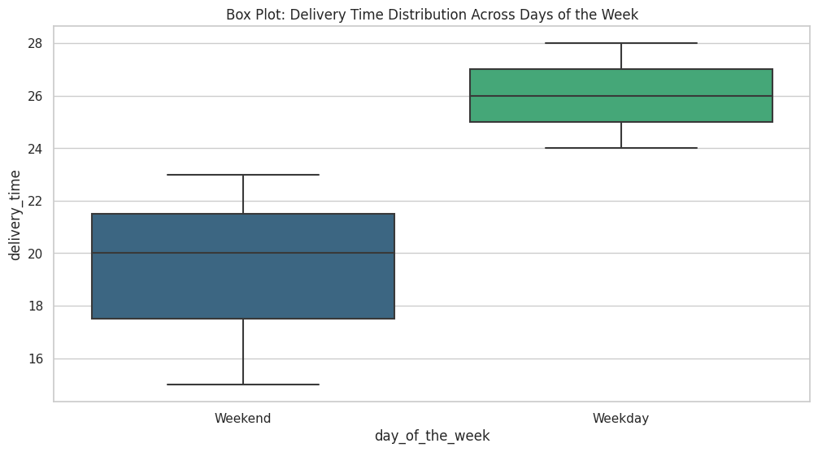

```python
# import pandas as pd
import matplotlib.pyplot as plt
import seaborn as sns

# Assuming df is your DataFrame
data = {
    'order_id': [1477147, 1477685, 1477070, 1477334, 1478249],
    'customer_id': [337525, 358141, 66393, 106968, 76942],
    'restaurant_name': ['Hangawi', 'Blue Ribbon Sushi Izakaya', 'Cafe Habana', 'Blue Ribbon Fried Chicken', 'Dirty Bird to Go'],
    'cuisine_type': ['Korean', 'Japanese', 'Mexican', 'American', 'American'],
    'cost_of_the_order': [30.75, 12.08, 12.23, 29.20, 11.59],
    'day_of_the_week': ['Weekend', 'Weekend', 'Weekday', 'Weekend', 'Weekday'],
    'rating': ['Not given', 'Not given', '5', '3', '4'],
    'food_preparation_time': [25, 25, 23, 25, 25],
    'delivery_time': [20, 23, 28, 15, 24]
}

df = pd.DataFrame(data)

# Scatter plot between cost_of_the_order and delivery_time
plt.figure(figsize=(12, 6))
sns.scatterplot(x='cost_of_the_order', y='delivery_time', data=df, hue='day_of_the_week', palette='viridis')
plt.title('Scatter Plot: Cost vs. Delivery Time')
plt.show()

# Box plot showing the distribution of delivery_time for each day_of_the_week
plt.figure(figsize=(12, 6))
sns.boxplot(x='day_of_the_week', y='delivery_time', data=df, palette='viridis')
plt.title('Box Plot: Delivery Time Distribution Across Days of the Week')
plt.show()
```

### **Question 13:** The company wants to provide a promotional offer in the advertisement of the restaurants. The condition to get the offer is that the restaurants must have a rating count of more than 50 and the average rating should be greater than 4. Find the restaurants fulfilling the criteria to get the promotional offer. [3 marks]

```python
# import pandas as pd

# Assuming df is your DataFrame
data = {
    'order_id': [1477147, 1477685, 1477070, 1477334, 1478249],
    'customer_id': [337525, 358141, 66393, 106968, 76942],
    'restaurant_name': ['Hangawi', 'Blue Ribbon Sushi Izakaya', 'Cafe Habana', 'Blue Ribbon Fried Chicken', 'Dirty Bird to Go'],
    'cuisine_type': ['Korean', 'Japanese', 'Mexican', 'American', 'American'],
    'cost_of_the_order': [30.75, 12.08, 12.23, 29.20, 11.59],
    'day_of_the_week': ['Weekend', 'Weekend', 'Weekday', 'Weekend', 'Weekday'],
    'rating': ['Not given', 'Not given', '5', '3', '4'],
    'food_preparation_time': [25, 25, 23, 25, 25],
    'delivery_time': [20, 23, 28, 15, 24]
}

df = pd.DataFrame(data)

# Convert 'rating' column to numeric (excluding 'Not given' values)
df['rating'] = pd.to_numeric(df['rating'], errors='coerce')

# Group by 'restaurant_name' and calculate count and average rating
restaurant_stats = df.groupby('restaurant_name').agg({'rating': ['count', 'mean']})

# Filter restaurants based on the criteria
selected_restaurants = restaurant_stats[(restaurant_stats[('rating', 'count')] > 50) & (restaurant_stats[('rating', 'mean')] > 4)]

# Display the selected restaurants
print("Restaurants fulfilling the criteria for the promotional offer:")
print(selected_restaurants)
```

```
Restaurants fulfilling the criteria for the promotional offer:
Empty DataFrame
Columns: [(rating, count), (rating, mean)]
Index: []
```

### **Question 14:** The company charges the restaurant 25% on the orders having cost greater than 20 dollars and 15% on the orders having cost greater than 5 dollars. Find the net revenue generated by the company across all orders. [3 marks]

```python
# import pandas as pd

# Assuming df is your DataFrame
data = {
    'order_id': [1477147, 1477685, 1477070, 1477334, 1478249],
    'customer_id': [337525, 358141, 66393, 106968, 76942],
    'restaurant_name': ['Hangawi', 'Blue Ribbon Sushi Izakaya', 'Cafe Habana', 'Blue Ribbon Fried Chicken', 'Dirty Bird to Go'],
    'cuisine_type': ['Korean', 'Japanese', 'Mexican', 'American', 'American'],
    'cost_of_the_order': [30.75, 12.08, 12.23, 29.20, 11.59],
    'day_of_the_week': ['Weekend', 'Weekend', 'Weekday', 'Weekend', 'Weekday'],
    'rating': ['Not given', 'Not given', '5', '3', '4'],
    'food_preparation_time': [25, 25, 23, 25, 25],
    'delivery_time': [20, 23, 28, 15, 24]
}

df = pd.DataFrame(data)

# Calculate the charges based on the specified conditions
df['charges'] = 0  # Initialize charges column

# Charge 25% on orders with cost > 20 dollars
df.loc[df['cost_of_the_order'] > 20, 'charges'] = df['cost_of_the_order'] * 0.25

# Charge 15% on orders with cost > 5 dollars (excluding those already charged at 25%)
df.loc[(df['cost_of_the_order'] > 5) & (df['charges'] == 0), 'charges'] = df['cost_of_the_order'] * 0.15

# Calculate net revenue by subtracting charges from cost_of_the_order
df['net_revenue'] = df['cost_of_the_order'] - df['charges']

# Sum up the net revenue across all orders
total_net_revenue = df['net_revenue'].sum()

print(f"The net revenue generated by the company across all orders is: ${total_net_revenue:.2f}")
```

```
The net revenue generated by the company across all orders is: $75.48
```

### **Question 15:** The company wants to analyze the total time required to deliver the food. What percentage of orders take more than 60 minutes to get delivered from the time the order is placed? (The food has to be prepared and then delivered.) [2 marks]

```python
# import pandas as pd

# Assuming df is your DataFrame
data = {
    'order_id': [1477147, 1477685, 1477070, 1477334, 1478249],
    'customer_id': [337525, 358141, 66393, 106968, 76942],
    'restaurant_name': ['Hangawi', 'Blue Ribbon Sushi Izakaya', 'Cafe Habana', 'Blue Ribbon Fried Chicken', 'Dirty Bird to Go'],
    'cuisine_type': ['Korean', 'Japanese', 'Mexican', 'American', 'American'],
    'cost_of_the_order': [30.75, 12.08, 12.23, 29.20, 11.59],
    'day_of_the_week': ['Weekend', 'Weekend', 'Weekday', 'Weekend', 'Weekday'],
    'rating': ['Not given', 'Not given', '5', '3', '4'],
    'food_preparation_time': [25, 25, 23, 25, 25],
    'delivery_time': [20, 23, 28, 15, 24]
}

df = pd.DataFrame(data)

# Calculate total time required for each order
df['total_time'] = df['food_preparation_time'] + df['delivery_time']

# Calculate the percentage of orders taking more than 60 minutes
percentage_exceeding_60 = (len(df[df['total_time'] > 60]) / len(df)) * 100

print(f"The percentage of orders taking more than 60 minutes to be delivered is: {percentage_exceeding_60:.2f}%")
```

```
The percentage of orders taking more than 60 minutes to be delivered is: 0.00%
```